# Modele liniowe

## Konfiguracja

Użyjemy standardowego stosu narzędzi do tabelarycznego uczenia maszynowego w Pythonie: Numpy, Pandas, Matplotlib i Scikit-learn. Użyjemy też missingno dla łatwej wizualizacji wartości brakujących.

```python
# !pip install numpy pandas matplotlib scikit-learn missingno
```

```python
import matplotlib.pyplot as plt
import numpy as np
import pandas as pd
```

## Zbiór danych do regresji

Wykorzystamy zbiór danych [Ames housing](https://www.openintro.org/book/statdata/?data=ames), w którym zadaniem jest przewidywanie wartości domu na podstawie cech budynku, działki, lokalizacji itp. Jest to więc przewidywanie wartości ciągłej, czyli regresja. Obejmuje zmienne do usunięcia (np. ID transakcji), numeryczne (floaty i inty), kategoryczne nieuporządkowane (*categorical nominal*) oraz kategoryczne uporządkowane (*categorical ordinal*), więc będzie wymagał wstępnego przetworzenia tak jak większość prawdziwych danych w ML.

Inne znane, ale gorsze jakościowo zbiory tego typu to na przykład:

- Boston housing - rasistowski, z tego powodu usunięty np. ze Scikit-learn ([wyjaśnienie](https://fairlearn.org/main/user_guide/datasets/boston_housing_data.html), [dyskusja](https://github.com/quantumblacklabs/causalnex/issues/92), [badanie](https://medium.com/@docintangible/racist-data-destruction-113e3eff54a8))
- California housing - zbyt prosty (tylko kilka zmiennych numerycznych), użyty np. w książce "Hands-On Machine Learning with Scikit-Learn, Keras, and TensorFlow" A. Geron ([opis](https://inria.github.io/scikit-learn-mooc/python_scripts/datasets_california_housing.html))

Autor zbioru to Dean De Cock, a zbiór został opisany oryginalnie w [tym artykule](https://jse.amstat.org/v19n3/decock.pdf). Szczegółowe opisy zmiennych znajdują się w pliku `ames_description.txt`.

```python
df = pd.read_csv("ames_data.csv")

# remove dots from names to match data_description.txt
df.columns = [col.replace(".", "") for col in df.columns]

df.head()
```

|  | Order | PID | MSSubClass | MSZoning | LotFrontage | LotArea | Street | Alley | LotShape | LandContour | ... | PoolArea | PoolQC | Fence | MiscFeature | MiscVal | MoSold | YrSold | SaleType | SaleCondition | SalePrice |
| --- | --- | --- | --- | --- | --- | --- | --- | --- | --- | --- | --- | --- | --- | --- | --- | --- | --- | --- | --- | --- | --- |
| 0 | 1 | 526301100 | 20 | RL | 141.0 | 31770 | Pave | NaN | IR1 | Lvl | ... | 0 | NaN | NaN | NaN | 0 | 5 | 2010 | WD | Normal | 215000 |
| 1 | 2 | 526350040 | 20 | RH | 80.0 | 11622 | Pave | NaN | Reg | Lvl | ... | 0 | NaN | MnPrv | NaN | 0 | 6 | 2010 | WD | Normal | 105000 |
| 2 | 3 | 526351010 | 20 | RL | 81.0 | 14267 | Pave | NaN | IR1 | Lvl | ... | 0 | NaN | NaN | Gar2 | 12500 | 6 | 2010 | WD | Normal | 172000 |
| 3 | 4 | 526353030 | 20 | RL | 93.0 | 11160 | Pave | NaN | Reg | Lvl | ... | 0 | NaN | NaN | NaN | 0 | 4 | 2010 | WD | Normal | 244000 |
| 4 | 5 | 527105010 | 60 | RL | 74.0 | 13830 | Pave | NaN | IR1 | Lvl | ... | 0 | NaN | MnPrv | NaN | 0 | 3 | 2010 | WD | Normal | 189900 |

5 rows × 82 columns

```python
df.shape
```

```
(2930, 82)
```

## Eksploracja danych, czyszczenie danych i inżynieria cech

Wstępne czyszczenie danych (*data cleaning*) obejmuje:

- usunięcie kolumn `Order` oraz `PID`
- usunięcie obserwacji odstających (*outliers*), które mają powyżej 4000 stóp kwadratowych (ok. 370 metrów kwadratowych) powierzchni
- usunięcie wpisów z dzielnic `GrnHill` oraz `Landmrk`, które obejmują w sumie zaledwie 3 domy
- transformacja logarytmiczna zmiennej zależnej (ceny domu)

To drugie jest motywowane wykresem przedstawionym poniżej. Zostało uznane za błąd już przez samego autora.

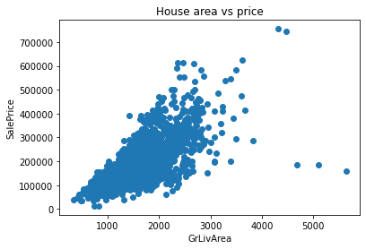

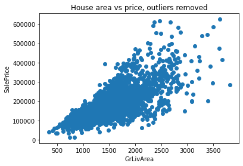

```python
df = df.drop(["Order", "PID"], axis="columns")
df = df.loc[~df["Neighborhood"].isin(["GrnHill", "Landmrk"]), :]

plt.scatter(df["GrLivArea"], df["SalePrice"])
plt.title("House area vs price")
plt.xlabel("GrLivArea")
plt.ylabel("SalePrice")
plt.show()

df = df.loc[df["GrLivArea"] <= 4000, :]

plt.scatter(df["GrLivArea"], df["SalePrice"])
plt.title("House area vs price, outliers removed")
plt.xlabel("GrLivArea")
plt.ylabel("SalePrice")
plt.show()
```

```python
df = df.loc[df["GrLivArea"] <= 4000, :]
```

Zawsze warto też przyjrzeć się rozkładowi zmiennej docelowej, żeby poznać jego typ i skalę. Jak widać poniżej, rozkład jest dość skośny, co ma sens - mało jest bardzo drogich domów.

Rozkład normalny jest zwykle korzystniejszy dla tworzenia modeli, bo daje sensowną "wartość środkową" do przewidywania, a także penalizuje tak samo mylenie się w obie strony (zaniżona i zawyżona predykcja). Dokonamy dlatego **transformacji logarytmicznej (log transform)**, czyli zlogarytmujemy zmienną docelową (zależną). Dla stabilności numerycznej używa się zwykle `np.log1p`, a nie `np.log`.

Dodatkowa korzyść z takiej transformacji jest taka, że regresja liniowa przewiduje dowolne wartości rzeczywiste. Po przekształceniu logarytmicznym jest to całkowicie ok, natomiast w oryginalnej przestrzeni trzeba by wymusić przewidywanie tylko wartości pozytywnych (negatywne ceny są bez sensu). Da się to zrobić, ale zwiększa to koszt obliczeniowy. Operowanie na tzw. log-price jest bardzo częste w finansach.

**Uwaga:** - upewnij się, żeby nie wykonać komórki z kodem logarytmowania więcej niż raz, bo wtedy zlogarytmujesz wartości docelowe ponownie.

```python
df["SalePrice"].describe()
```

```
count      2922.000000
mean     180358.266940
std       78536.952287
min       12789.000000
25%      129425.000000
50%      160000.000000
75%      213430.000000
max      625000.000000
Name: SalePrice, dtype: float64
```

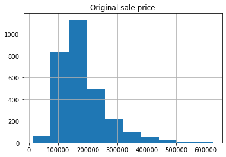

[figure not shown]

```python
df["SalePrice"].hist()
plt.title("Original sale price")
plt.show()

df.loc[:, "SalePrice"] = np.log1p(df.loc[:, "SalePrice"])

pd.Series(np.log(df["SalePrice"])).hist()
plt.title("Log sale price")
plt.show()
```

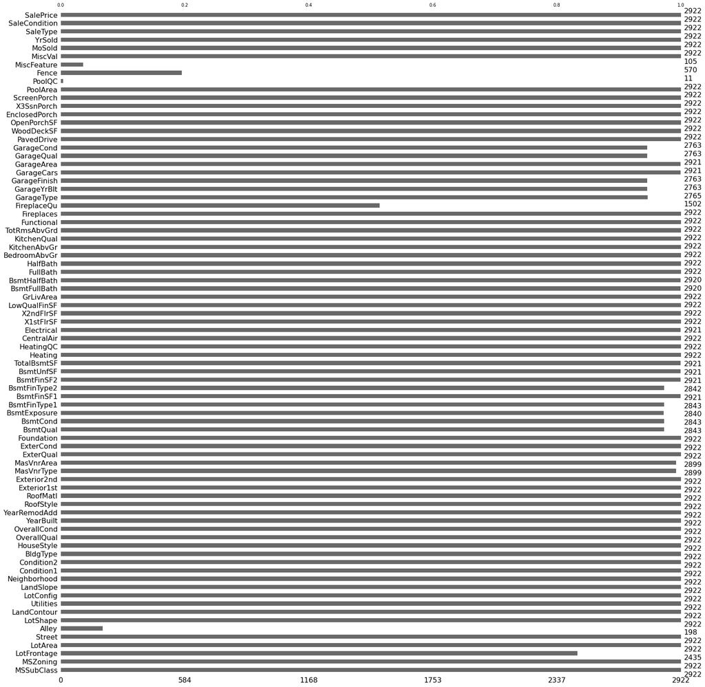

```python
import missingno as msno

msno.bar(df)
```

W ramach dalszego czyszczenia danych uzupełnimy wartości brakujące. Trzeba tu jednak wziąć pod uwagę:

- mamy dużo zmiennych kategorycznych - nie można w nich dokonać imputacji modą, medianą itp.
- mamy często dużo wartości brakujących - estymacja modą byłaby niedokładna
- mamy dużą wiedzę o zmiennych dzięki plikowi z opisami

Można więc zastosować odpowiednią wiedzę i przyjąć wartości domyślne. Przykładowo, brak informacji o powierzchni piwnicy możemy uznać po prostu za brak piwnicy, i wpisać tam odpowiednią wartość. W przypadku niektórych zmiennych może doprowadzić to do stworzenia nowej wartości, która implicite będzie reprezentować wartość brakującą.

Znaczna część poniższej analizy została zainspirowana [tym notebookiem na Kaggle](https://www.kaggle.com/code/juliencs/a-study-on-regression-applied-to-the-ames-dataset).

```python
def replace_na(df: pd.DataFrame, col: str, value) -> None:
    df.loc[:, col] = df.loc[:, col].fillna(value)
```

```python
# Alley : data description says NA means "no alley access"
replace_na(df, "Alley", value="None")

# BedroomAbvGr : NA most likely means 0
replace_na(df, "BedroomAbvGr", value=0)

# BsmtQual etc : data description says NA for basement features is "no basement"
replace_na(df, "BsmtQual", value="No")
replace_na(df, "BsmtCond", value="No")
replace_na(df, "BsmtExposure", value="No")
replace_na(df, "BsmtFinType1", value="No")
replace_na(df, "BsmtFinType2", value="No")
replace_na(df, "BsmtFullBath", value=0)
replace_na(df, "BsmtHalfBath", value=0)
replace_na(df, "BsmtUnfSF", value=0)

# Condition : NA most likely means Normal
replace_na(df, "Condition1", value="Norm")
replace_na(df, "Condition2", value="Norm")

# External stuff : NA most likely means average
replace_na(df, "ExterCond", value="TA")
replace_na(df, "ExterQual", value="TA")

# Fence : data description says NA means "no fence"
replace_na(df, "Fence", value="No")

# Functional : data description says NA means typical
replace_na(df, "Functional", value="Typ")

# GarageType etc : data description says NA for garage features is "no garage"
replace_na(df, "GarageType", value="No")
replace_na(df, "GarageFinish", value="No")
replace_na(df, "GarageQual", value="No")
replace_na(df, "GarageCond", value="No")
replace_na(df, "GarageArea", value=0)
replace_na(df, "GarageCars", value=0)

# HalfBath : NA most likely means no half baths above grade
replace_na(df, "HalfBath", value=0)

# HeatingQC : NA most likely means typical
replace_na(df, "HeatingQC", value="Ta")

# KitchenAbvGr : NA most likely means 0
replace_na(df, "KitchenAbvGr", value=0)

# KitchenQual : NA most likely means typical
replace_na(df, "KitchenQual", value="TA")

# LotFrontage : NA most likely means no lot frontage
replace_na(df, "LotFrontage", value=0)

# LotShape : NA most likely means regular
replace_na(df, "LotShape", value="Reg")

# MasVnrType : NA most likely means no veneer
replace_na(df, "MasVnrType", value="None")
replace_na(df, "MasVnrArea", value=0)

# MiscFeature : data description says NA means "no misc feature"
replace_na(df, "MiscFeature", value="No")
replace_na(df, "MiscVal", value=0)

# OpenPorchSF : NA most likely means no open porch
replace_na(df, "OpenPorchSF", value=0)

# PavedDrive : NA most likely means not paved
replace_na(df, "PavedDrive", value="N")

# PoolQC : data description says NA means "no pool"
replace_na(df, "PoolQC", value="No")
replace_na(df, "PoolArea", value=0)

# ScreenPorch : NA most likely means no screen porch
replace_na(df, "ScreenPorch", value=0)

# TotRmsAbvGrd : NA most likely means 0
replace_na(df, "TotRmsAbvGrd", value=0)

# Utilities : NA most likely means all public utilities
replace_na(df, "Utilities", value="AllPub")

# WoodDeckSF : NA most likely means no wood deck
replace_na(df, "WoodDeckSF", value=0)

# FireplaceQu : data description says NA means "no fireplace"
replace_na(df, "FireplaceQu", value="No")
```

**Zadanie 1 (0.5 punktu)**

Z pomocą dokumentacji zmiennych w pliku `data_description.txt` zdecyduj, jakie wartości domyślne przypisać zmiennym:

- `CentralAir`
- `EnclosedPorch`
- `Fireplaces`
- `SaleCondition`

W praktyce niestety zwykle nie jest tak różowo, że mamy dokumentację, i ten krok zajmuje kilka godzin (lub dni) u różnych osób w firmie :)

```python
# CentralAir : NA most likely means N (no) central air conditioning
replace_na(df, "CentralAir", value="N")

# EnclosedPorch : NA most likely means no enclosed porch area - 0 squre feet
replace_na(df, "EnclosedPorch", value=0)

# Fireplaces : NA most likely means no fire places - 0
replace_na(df, "Fireplaces", value=0)

# SaleCondition : NA most likely means Normal sale condition
replace_na(df, "SaleCondition", value="Normal")
```

W dalszej kolejności zamienimy zmienne `MSSubClass` i `MoSold` z numerycznych na kategoryczne, zgodnie z ich znaczeniem. Zakodujemy także zmienne kategoryczne uporządkowane (categorical ordinal) z tekstowych na kolejne liczby całkowite.

```python
df = df.replace(
    {
        "MSSubClass": {
            20: "SC20",
            30: "SC30",
            40: "SC40",
            45: "SC45",
            50: "SC50",
            60: "SC60",
            70: "SC70",
            75: "SC75",
            80: "SC80",
            85: "SC85",
            90: "SC90",
            120: "SC120",
            150: "SC150",
            160: "SC160",
            180: "SC180",
            190: "SC190",
        },
        "MoSold": {
            1: "Jan",
            2: "Feb",
            3: "Mar",
            4: "Apr",
            5: "May",
            6: "Jun",
            7: "Jul",
            8: "Aug",
            9: "Sep",
            10: "Oct",
            11: "Nov",
            12: "Dec",
        },
    }
)
```

```python
df = df.replace(
    {
        "Alley": {"None": 0, "Grvl": 1, "Pave": 2},
        "BsmtCond": {"No": 0, "Po": 1, "Fa": 2, "TA": 3, "Gd": 4, "Ex": 5},
        "BsmtExposure": {"No": 0, "Mn": 1, "Av": 2, "Gd": 3},
        "BsmtFinType1": {
            "No": 0,
            "Unf": 1,
            "LwQ": 2,
            "Rec": 3,
            "BLQ": 4,
            "ALQ": 5,
            "GLQ": 6,
        },
        "BsmtFinType2": {
            "No": 0,
            "Unf": 1,
            "LwQ": 2,
            "Rec": 3,
            "BLQ": 4,
            "ALQ": 5,
            "GLQ": 6,
        },
        "BsmtQual": {"No": 0, "Po": 1, "Fa": 2, "TA": 3, "Gd": 4, "Ex": 5},
        "ExterCond": {"Po": 1, "Fa": 2, "TA": 3, "Gd": 4, "Ex": 5},
        "ExterQual": {"Po": 1, "Fa": 2, "TA": 3, "Gd": 4, "Ex": 5},
        "FireplaceQu": {"No": 0, "Po": 1, "Fa": 2, "TA": 3, "Gd": 4, "Ex": 5},
        "Functional": {
            "Sal": 1,
            "Sev": 2,
            "Maj2": 3,
            "Maj1": 4,
            "Mod": 5,
            "Min2": 6,
            "Min1": 7,
            "Typ": 8,
        },
        "GarageCond": {"No": 0, "Po": 1, "Fa": 2, "TA": 3, "Gd": 4, "Ex": 5},
        "GarageQual": {"No": 0, "Po": 1, "Fa": 2, "TA": 3, "Gd": 4, "Ex": 5},
        "HeatingQC": {"Po": 1, "Fa": 2, "TA": 3, "Gd": 4, "Ex": 5},
        "KitchenQual": {"Po": 1, "Fa": 2, "TA": 3, "Gd": 4, "Ex": 5},
        "LandSlope": {"Sev": 1, "Mod": 2, "Gtl": 3},
        "LotShape": {"IR3": 1, "IR2": 2, "IR1": 3, "Reg": 4},
        "PavedDrive": {"N": 0, "P": 1, "Y": 2},
        "PoolQC": {"No": 0, "Fa": 1, "TA": 2, "Gd": 3, "Ex": 4},
        "Street": {"Grvl": 1, "Pave": 2},
        "Utilities": {"ELO": 1, "NoSeWa": 2, "NoSewr": 3, "AllPub": 4},
    }
)
```

W Pandasie zmienne kategoryczne, napisy itp. są typu `object`, natomiast numeryczne mają typy z Numpy'a, np. `int64`. Oczywiście oba rodzaje zmiennych trzeba przetwarzać na inne sposoby, więc zapiszemy to od razu. Wyodrębnimy też wektor docelowy.

Od razu dokonamy też podziału na zbiór treningowy i testowy. Jako że nasz zbiór jest dość mały, to podział będzie 70%-30%.

```python
from sklearn.model_selection import train_test_split

y = df.pop("SalePrice")

categorical_features = df.select_dtypes(include="object").columns
numerical_features = df.select_dtypes(exclude="object").columns

X_train, X_test, y_train, y_test = train_test_split(
    df, y, test_size=0.3, random_state=0
)
```

Teraz trzeba dokonać transformacji naszych danych:

- zmienne kategoryczne trzeba zamienić na osobne kolumny - **one-hot encoding**
- zmienne numeryczne dalej mogą mieć wartości brakujące i trzeba je **imputować (impute**)
- zmienne numeryczne trzeba przeskalować do zakresu wartości $[0, 1]$ - **normalization / min-max scaling**

Mamy zatem 2 operacje do wykonania na zmiennych numerycznych po kolei (imputacja + skalowanie), a równolegle 1 na kategorycznych. Służą do tego w Scikit-learn'ie klasy:

- `OneHotEncoder`, `SimpleImputer`, `MinMaxScaler` - transformacje, implementują `.fit()` i `.transform()`
- `Pipeline` - do układania transformacji sekwencyjnie
- `ColumnTransformer` - do układania transformacji równolegle, dla różnych kolumn

**Ważne:** jako że zaraz skorzystamy z regresji liniowej, do klasy `OneHotEncoder` trzeba przekazać `drop="first"`. Stworzy to 1 zmienną mniej, niż typowy one-hot encoding, np. `pd.get_dummies()`, gwarantując brak **idealnie współliniowych zmiennych (perfectly collinear features)**, który byłby niestabilny numerycznie. Dodatkowo, jako że przekształcamy już po podziale na zbiór treningowy i testowy, to możemy spotkać na zbiorze testowym nieliczne przypadki kategorii, których nie ma w zbiorze treningowym - kodujemy je wtedy po prostu jako zera za pomocą `handle_unknown="ignore"`.

**Zadanie 2 (0.5 punktu)**

Stwórz pipeline'y dla zmiennych kategorycznych i numerycznych. Połącz je następnie z użyciem `ColumnTransformer`. "Wytrenuj" go na danych treningowych, a następnie przetransformuj dane treningowe oraz testowe.

```python
from sklearn.compose import ColumnTransformer
from sklearn.impute import SimpleImputer
from sklearn.pipeline import Pipeline
from sklearn.preprocessing import OneHotEncoder, MinMaxScaler


one_hot_encoder = OneHotEncoder(
    drop="first", sparse_output=False, handle_unknown="ignore"
)
median_imputer = SimpleImputer(strategy="median")
min_max_scaler = MinMaxScaler()

categorical_pipeline = Pipeline([('one_hot_encoder', one_hot_encoder)])

numerical_pipeline = Pipeline([('imputation', median_imputer), ('normalization', min_max_scaler)])

column_transformer = ColumnTransformer([("cat_pipeline", categorical_pipeline, categorical_features), ("num_pipeline", numerical_pipeline, numerical_features)])

# fit and transform

X_train = column_transformer.fit_transform(X_train)
X_test = column_transformer.transform(X_test)
```

#### OneHotEncoder

```python
enc = OneHotEncoder(handle_unknown='ignore')
```

```python
# X = [['Male', 1, 1, "hello"], ['Female', 3, 1, "hello"], ['Female', 2, 5, "hello"]]
X = [['Male', 1], ['Female', 3], ['Female', 2]]
enc.fit(X)
enc.categories_
```

```
[array(['Female', 'Male'], dtype=object), array([1, 2, 3], dtype=object)]
```

```python
enc.transform([['Female', 1], ['Male', 4], ['Male', 1]]).toarray()
```

```
array([[1., 0., 1., 0., 0.],
       [0., 1., 0., 0., 0.],
       [0., 1., 1., 0., 0.]])
```

```python
enc.inverse_transform([[1, 0, 0, 2, 0], [0, 1, 0, 0, 1]])
```

```
array([['Female', 2],
       ['Male', 3]], dtype=object)
```

```python
enc.get_feature_names_out(['gender', 'group'])
```

```
array(['gender_Female', 'gender_Male', 'group_1', 'group_2', 'group_3'],
      dtype=object)
```

#### OneHotEncoder(drop="first")

```python
drop_enc = OneHotEncoder(drop='first').fit(X)
drop_enc.categories_
```

```
[array(['Female', 'Male'], dtype=object), array([1, 2, 3], dtype=object)]
```

```python
drop_enc.transform([['Female', 1], ['Male', 3], ['Male', 1]]).toarray()
```

```
array([[0., 0., 0.],
       [1., 0., 1.],
       [1., 0., 0.]])
```

**Fit** method -> learn model parameters (e.g. mean and standard deviation for normalisation) from a training set.

**Transform** method -> apply these trasnformation model to unseed data.

**Transformers** - estimators having a *transform* method.

### Pipeline

Pipeline - used to chain multiple estimators into one.

Sequentially apply a list of transforms and a final estimator.

## Regresja liniowa

Możemy teraz przejść do przewidywania wartości domów. Naszym narzędziem będzie tutaj **regresja liniowa (linear regression)**, czyli model postaci: $$ \hat{y} = w \cdot x = \sum_{i=1}^{d} w_i x_i $$ gdzie $n$ to liczba punktów w zbiorze, a $d$ to wymiarowość. Zakładamy też dodanie punktu przecięcia ze środkiem układu współrzędnych (*bias / intercept*) jako stałej cechy samych jedynek.

Jako że używamy wielu zmiennych, to formaliści nazwaliby ten model wielokrotną regresją liniową (*multiple linear regression*), w odróżnieniu od prostej regresji liniowej (*simple linear regression*), która używa tylko 1 cechy. Takie rozróżnienie jest bardziej typowe dla nauk, które wykorzystują regresję głównie do analizy statystycznej, a nie predykcji, jak np. biologia czy medycyna.

Model ten minimalizuje **błąd średniokwadratowy (mean squared error, MSE)**: $$ L(y, \hat{y}) = \frac{1}{n} \sum_{i=1}^n \left( y - \hat{y} \right)^2 $$

W Scikit-learn ten model implementuje klasa `LinearRegression`. Ważne cechy:

- domyślnie uwzględnia intercept (bias) przez `fit_intercept=True`; jest to niepotrzebne i może powodować problemy numeryczne, kiedy nasze dane są już wycentrowane
- używa implementacji z pseudoodwrotnością Moore'a-Pendrose'a (SVD)
- nie pozwala na regularyzację, do tego trzeba użyć innych klas

Sprawdźmy, jak taki model sobie radzi. Do ewaluacji będziemy używać **Root MSE (RMSE)**, czyli pierwiastka kwadratowego z MSE. Ma ważne zalety:

- regresja liniowa z definicji modelu opiera się o MSE, więc używamy metryki dobrze związanej z modelem
- ma tę samą jednostkę, co przewidywane wartości, dzięki pierwiastkowaniu Jest też dość czuła na outliery, ale może to być korzystne, w zależności od zastosowania.

$$ RMSE(y, \hat{y}) = \sqrt{\sum_{i=1}^n (y_i - \hat{y}_i)^2} $$

W Scikit-learn RMSE liczy się dość specyficznie, bo używa się funkcji do MSE z argumentem `squared=False`.

```python
from sklearn.metrics import mean_squared_error
from sklearn.linear_model import LinearRegression

# all variables are in range [0, 1], so we don't need an intercept
reg_linear = LinearRegression(fit_intercept=False)
reg_linear.fit(X_train, y_train)

y_pred = reg_linear.predict(X_test)
rmse = mean_squared_error(y_test, y_pred, squared=False)

print(f"RMSE: {rmse:.4f}")
```

```
RMSE: 0.1159
```

Czy taki błąd to duży, czy mały błąd? Wszystko zależy od skali wartości przewidywanych. Trzeba pamiętać, że dokonaliśmy logarytmowania zmiennej docelowej, więc trzeba to sprawdzić po transformacji odwrotnej `np.expm1`. Po tej operacji jednostką będą oryginalne dolary.

Dodatkowo trzeba zweryfikować, czy przeuczamy (overfitujemy). Sprawdza się to następująco:

- obliczamy błąd treningowy oraz testowy
- jeżeli oba błędy są wysokie, to mamy underfitting i trzeba użyć pojemniejszego modelu
- jeżeli błąd treningowy jest dużo niższy od testowego, to mamy overfitting i trzeba regularyzować

W praktyce paradoksalnie często model o większej pojemności z mocną regularyzacją działa lepiej od prostszego modelu ze słabą regularyzacją.

**Zadanie 3 (0.5 punktu)**

Uzupełnij kod funkcji `assess_regression_model`:

- obliczenie predykcji treningowych oraz testowych
- transformacje eksponencjalne, żeby wrócić do oryginalnej jednostki (dolara)
- obliczenie RMSE treningowego i testowego
- wypisywanie RMSE, zoakrąglonego do 2 miejsc po przecinku

Użyj następnie tej funkcji, aby ocenić, czy następuje overfitting, skomentuj to poniżej. Oceń także, czy subiektywnie to duża wartość, biorąc pod uwagę rozkład zmiennej docelowej (wartości i wykresy w sekcji EDA).

```python
def assess_regression_model(model, X_train, X_test, y_train, y_test) -> None:
    # predict for train and test
    y_pred_train = model.predict(X_train)
    y_pred = model.predict(X_test)

    # exponential transform for y_train, y_test and predictions
    y_train_exp = np.expm1(y_train)
    y_test_exp = np.expm1(y_test)
    y_pred_train_exp, y_pred_exp = np.expm1(y_pred_train), np.expm1(y_pred)

    # calculate train and test RMSE
    rmse_train = mean_squared_error(y_train_exp, y_pred_train_exp, squared=False)
    rmse_test = mean_squared_error(y_test_exp, y_pred_exp, squared=False)

    # print train and test RMSE
    print(f"Train RMSE after np.expm1 on y: {rmse_train:.2f}")
    print(f"Test RMSE after np.expm1 on y: {rmse_test:.2f}")
```

```python
assess_regression_model(reg_linear, X_train, X_test, y_train, y_test)
```

```
Train RMSE after np.expm1 on y: 16751.11
Test RMSE after np.expm1 on y: 21318.61
```

```python
np.expm1(y).describe()
```

```
count      2922.000000
mean     180358.266940
std       78536.952287
min       12789.000000
25%      129425.000000
50%      160000.000000
75%      213430.000000
max      625000.000000
Name: SalePrice, dtype: float64
```

// skomentuj tutaj

Biorąc pod uwagę, że odchylenie standardowe wyniosło ok. 79 tyś, a nasze RMSE ok. 21 tyś, to wydaje się, że błąd RMSE naszego modelu jest stosunkowo niewielki. Jednocześnie RMSE dla zbioru treningowego i testowego są tego samego rzędu wielkości, dość podobne, ale pewnie różnicę między nimi dałoby się zmniejszyć.

## Regresja regularyzowana (ridge, LASSO)

Regularyzacja zmniejsza pojemność modelu regresji liniowej, narzucając mniejsze wagi poprzez penalizację dużych wag w funkcji kosztu: $$ L_{ridge}(y, \hat{y}) = \frac{1}{n} (y - \hat{y})^2 + \lambda ||w||_2^2 \\ L_{LASSO}(y, \hat{y}) = \frac{1}{n} (y - \hat{y})^2 + \alpha ||w||_1 \\ L_{ElasticNet}(y, \hat{y}) = \frac{1}{n} (y - \hat{y})^2 + \lambda ||w||_2^2 + \alpha ||w||_1 \\ $$

Regresja ridge zmniejsza wagi i jest różniczkowalna (szybsza i łatwiejsza w treningu), natomiast regresja LASSO dokonuje selekcji cech, zmniejszając często wagi cech dokładnie do zera. Oba naraz realizuje model ElasticNet.

W Scikit-learn implementują je klasy `Ridge`, `Lasso` oraz `ElasticNet`. Najważniejszy hiperparametr każdego z tych modeli to siła regularyzacji, która we wszystkich klasach to `alpha`. Scikit-learn definiuje regularyzację ElasticNet dość specyficznie, za pomocą parametru `l1_ratio`, który wyznacza, jaki ułamek siły regularyzacji przypada dla L1, a jaki dla L2: $$ L_{ElasticNet}(y, \hat{y}) = \frac{1}{n} \sum_{i=1}^n \left( y - \hat{y} \right)^2 + \alpha \cdot (1 - L1\_ratio) \cdot ||w||_2^2 + \alpha \cdot L1\_ratio \cdot ||w||_1 \\ $$

Inne ważne uwagi:

- liczba iteracji `max_iter` wyznacza liczbę iteracji solwera; im więcej, tym dokładniejsze rozwiązanie, ale tym dłuższy czas obliczeń
- jeżeli `max_iter` będzie zbyt małe i algorytm nie osiągnie zbieżności, to dostaniemy ostrzeżenie, wtedy zwykle trzeba po prostu ją zwiększyć, np. 10-krotnie
- jeżeli nie potrzebujemy bardzo precyzyjnego rozwiązania, można ustawić większe `tol` dla przyspieszenia obliczeń

Jako że nasz model jest regularyzowany i nie ma ryzyka problemów numerycznych, to teraz już obliczamy intercept.

```python
from sklearn.linear_model import Ridge, Lasso

reg_ridge = Ridge(random_state=0)
reg_lasso = Lasso(random_state=0)

reg_ridge.fit(X_train, y_train)
reg_lasso.fit(X_train, y_train)

print("Ridge reg")
assess_regression_model(reg_ridge, X_train, X_test, y_train, y_test)
print()
print("Lasso reg")
assess_regression_model(reg_lasso, X_train, X_test, y_train, y_test)
```

```
Ridge reg
Train RMSE after np.expm1 on y: 16870.91
Test RMSE after np.expm1 on y: 18879.11

Lasso reg
Train RMSE after np.expm1 on y: 79579.79
Test RMSE after np.expm1 on y: 80091.99
```

```python
reg_ridge.score(X_test, y_test)
```

```
0.9269405530302247
```

W przypadku regularyzacji L2 domyślna siła regularyzacji (`alpha=1.0`) znacząco poprawiła wynik, natomiast w przypadku L1 mamy silny underfitting. Przyda się zastosować tutaj tuning hiperparametrów.

W przypadku regresji liniowej istnieją bardzo wydajne implementacje walidacji skrośnej, głównie dzięki prostocie tego modelu. W Scikit-learn są to odpowiednio `RidgeCV`, `LassoCV` oraz `ElasticNetCV`.

`RidgeCV` domyślnie wykorzystuje efektywną implementację Leave-One-Out Cross-Validation (LOOCV), w którym zbiorem walidacyjnym jest w danej chwili jedna próbka. Jest to możliwe dzięki pewnym sztuczkom opartym na algebrze liniowej, wyjaśnionych [w dokumentacji w kodzie](https://github.com/scikit-learn/scikit-learn/blob/8c9c1f27b7e21201cfffb118934999025fd50cca/sklearn/linear_model/_ridge.py#L1547) (dla zainteresowanych). Co ważne, jest to operacja o wiele szybsza niż osobne grid search + ridge regression, a nawet od `RidgeCV` z mniejszą liczbą foldów.

`LassoCV` oraz `ElasticNetCV` iterują od najmniejszych do największych wartości `alpha` (siły regularyzacji), używając rozwiązania dla mniejszej siły regularyzacji jako punktu początkowego dla kolejnej wartości. Odpowiada to po prostu dość inteligentnemu wyborowi punktu startowego w optymalizacji funkcji kosztu, a znacznie obniża koszt obliczeniowy.

**Zadanie 4 (0.5 punktu)**

Użyj klas `RidgeCV` oraz `LassoCV` do tuningu hiperparametrów.

Dla `RidgeCV` sprawdź 1000 wartości `[0.1, 100]` w skali liniowej - przyda się `np.linspace()`. Użyj LOOCV.

Dla `LassoCV` Scikit-learn sam dobierze wartości, musisz podać tylko liczbę wartości alfa do sprawdzenia - użyj 1000. Użyj 5-fold CV. Pamiętaj o podaniu `random_state=0` - solwer jest niedeterministyczny.

Wypisz znalezione optymalne wartości siły regularyzacji `.alpha_` dla obu modeli, zaokrąglone do 4 miejsca po przecinku dla czytelności.

Przetestuj modele z użyciem `assess_regression_model()`. Skomentuj wyniki. Czy udało się wyeliminować overfitting?

```python
from sklearn.linear_model import RidgeCV, LassoCV

reg_ridge_cv = RidgeCV(np.linspace(0.1, 100, 1000)).fit(X_train, y_train)
print(f"RidgeCV alpha : {reg_ridge_cv.alpha_:.4f}")

reg_lasso_cv = LassoCV(n_alphas=1000, random_state=0).fit(X_train, y_train)
print(f"LassoCV alpha : {reg_lasso_cv.alpha_:.4f}")
```

```
RidgeCV alpha : 2.9000
LassoCV alpha : 0.0003
```

```python
print("RidgeCV reg")
assess_regression_model(reg_ridge_cv, X_train, X_test, y_train, y_test)
```

```
RidgeCV reg
Train RMSE after np.expm1 on y: 17212.41
Test RMSE after np.expm1 on y: 18758.43
```

```python
print("LassoCV reg")
assess_regression_model(reg_lasso_cv, X_train, X_test, y_train, y_test)
```

```
LassoCV reg
Train RMSE after np.expm1 on y: 18108.04
Test RMSE after np.expm1 on y: 18664.62
```

// skomentuj tutaj

W obu przypadkach udało się wyeliminować overfitting , zbliżając do siebie wartości RMSE treningowego i testowego, jednocześnie zmniejszając RMSE testowe - co oznacza lepszy "wynik" modelu.

W przypadku **regularyzacji ridge**, RMSE testowy zmalał nieznacznie, treningowy zaś wzrósł nieznacznie - oznacza to, że wcześniejszy model ciut bardziej sugerował się danymi treningowymi.

W przypadku **regularyzacji lasso**, obserwujemy znaczący spadek obydwu wartości RMSE - oznacza to lepsze dopasowanie modelu. Jednocześnie RMSE treningowe i testowe są do siebie bardzo zbliżone - oznacza to, że udało się wyeliminować overfitting.

Sprawdźmy teraz, jak zmieniły się maksymalne wielkości współczynników (w sensie wartości bezwzględnej) dla cech dla regularyzacji L2, oraz ile cech zostało wyeliminowanych przez regularyzację L1.

**Uwaga:** kod zakłada, że zmienne to `reg_ridge_cv` oraz `reg_lasso_cv`. Jeżeli u ciebie są inne, dostosuj poniższy kod.

```python
coeffs_linear_max = np.max(np.abs(reg_linear.coef_))
coeffs_ridge_max = np.max(np.abs(reg_ridge.coef_))
coeffs_ridge_cv_max = np.max(np.abs(reg_ridge_cv.coef_))

coeffs_linear_zero_perc = np.sum(reg_linear.coef_ == 0) / len(reg_linear.coef_)
coeffs_lasso_zero_perc = np.sum(reg_lasso.coef_ == 0) / len(reg_linear.coef_)
coeffs_lasso_cv_zero_perc = np.sum(reg_lasso_cv.coef_ == 0) / len(reg_linear.coef_)

print("Coefficients magnitudes (linear, ridge, ridge with CV)")
print(
    f"Max: {coeffs_linear_max:.2f} vs",
    f"vs {coeffs_ridge_max:.2f} vs",
    f"{coeffs_ridge_cv_max:.2f}",
)
print()
print("Percentage of eliminated features (linear, LASSO, LASSO with CV)")
print(
    f"{100 * coeffs_linear_zero_perc:.2f}% vs",
    f"{100 * coeffs_lasso_zero_perc:.2f}% vs",
    f"{100 * coeffs_lasso_cv_zero_perc:.2f}%",
)
```

```
Coefficients magnitudes (linear, ridge, ridge with CV)
Max: 818.07 vs vs 0.52 vs 0.45

Percentage of eliminated features (linear, LASSO, LASSO with CV)
0.00% vs 100.00% vs 54.27%
```

**Zadanie 5 (0.5 punktu)**

// skomentuj tutaj

Gdy wyeliminowane zostały wszystkie cechy, oznacza to zbyt wysoką wartość alpha. Możliwa jest też duża współliniowość cech.

Warto zwrócić uwagę, że zbieranie i obliczanie cech jest często drogie w praktyce. W tym przypadku model z mniejszą ilością cech dodatkowo radzi sobie dobrze, więc jest tańszy i prostszy, są to znaczące zalety. Zawsze warto się przyjrzeć temu, co model uznaje za bardzo wartościowe oraz mało wartościowe cechy, bo daje nam to wiedzę, na czym się skupić w przyszłości.

Jako że dokonaliśmy wcześniej wielu transformacji, to nazwy kolumn są dość mocno poprzekształcane. Na szczęście wszystkie obiekty transformujące w Scikit-learn (z metodą `.transform()`) implementują też metodę `.get_feature_names_out()`.

```python
column_transformer.get_feature_names_out()
```

```
array(['cat_pipeline__MSSubClass_SC150', 'cat_pipeline__MSSubClass_SC160',
       'cat_pipeline__MSSubClass_SC180', 'cat_pipeline__MSSubClass_SC190',
       'cat_pipeline__MSSubClass_SC20', 'cat_pipeline__MSSubClass_SC30',
       'cat_pipeline__MSSubClass_SC40', 'cat_pipeline__MSSubClass_SC45',
       'cat_pipeline__MSSubClass_SC50', 'cat_pipeline__MSSubClass_SC60',
       'cat_pipeline__MSSubClass_SC70', 'cat_pipeline__MSSubClass_SC75',
       'cat_pipeline__MSSubClass_SC80', 'cat_pipeline__MSSubClass_SC85',
       'cat_pipeline__MSSubClass_SC90', 'cat_pipeline__MSZoning_C (all)',
       'cat_pipeline__MSZoning_FV', 'cat_pipeline__MSZoning_I (all)',
       'cat_pipeline__MSZoning_RH', 'cat_pipeline__MSZoning_RL',
       'cat_pipeline__MSZoning_RM', 'cat_pipeline__LandContour_HLS',
       'cat_pipeline__LandContour_Low', 'cat_pipeline__LandContour_Lvl',
       'cat_pipeline__LotConfig_CulDSac', 'cat_pipeline__LotConfig_FR2',
       'cat_pipeline__LotConfig_FR3', 'cat_pipeline__LotConfig_Inside',
       'cat_pipeline__Neighborhood_Blueste',
       'cat_pipeline__Neighborhood_BrDale',
       'cat_pipeline__Neighborhood_BrkSide',
       'cat_pipeline__Neighborhood_ClearCr',
       'cat_pipeline__Neighborhood_CollgCr',
       'cat_pipeline__Neighborhood_Crawfor',
       'cat_pipeline__Neighborhood_Edwards',
       'cat_pipeline__Neighborhood_Gilbert',
       'cat_pipeline__Neighborhood_Greens',
       'cat_pipeline__Neighborhood_IDOTRR',
       'cat_pipeline__Neighborhood_MeadowV',
       'cat_pipeline__Neighborhood_Mitchel',
       'cat_pipeline__Neighborhood_NAmes',
       'cat_pipeline__Neighborhood_NPkVill',
       'cat_pipeline__Neighborhood_NWAmes',
       'cat_pipeline__Neighborhood_NoRidge',
       'cat_pipeline__Neighborhood_NridgHt',
       'cat_pipeline__Neighborhood_OldTown',
       'cat_pipeline__Neighborhood_SWISU',
       'cat_pipeline__Neighborhood_Sawyer',
       'cat_pipeline__Neighborhood_SawyerW',
       'cat_pipeline__Neighborhood_Somerst',
       'cat_pipeline__Neighborhood_StoneBr',
       'cat_pipeline__Neighborhood_Timber',
       'cat_pipeline__Neighborhood_Veenker',
       'cat_pipeline__Condition1_Feedr', 'cat_pipeline__Condition1_Norm',
```

[output cut: 98 more lines]

```
       'num_pipeline__X2ndFlrSF', 'num_pipeline__LowQualFinSF',
       'num_pipeline__GrLivArea', 'num_pipeline__BsmtFullBath',
       'num_pipeline__BsmtHalfBath', 'num_pipeline__FullBath',
       'num_pipeline__HalfBath', 'num_pipeline__BedroomAbvGr',
       'num_pipeline__KitchenAbvGr', 'num_pipeline__KitchenQual',
       'num_pipeline__TotRmsAbvGrd', 'num_pipeline__Functional',
       'num_pipeline__Fireplaces', 'num_pipeline__FireplaceQu',
       'num_pipeline__GarageYrBlt', 'num_pipeline__GarageCars',
       'num_pipeline__GarageArea', 'num_pipeline__GarageQual',
       'num_pipeline__GarageCond', 'num_pipeline__PavedDrive',
       'num_pipeline__WoodDeckSF', 'num_pipeline__OpenPorchSF',
       'num_pipeline__EnclosedPorch', 'num_pipeline__X3SsnPorch',
       'num_pipeline__ScreenPorch', 'num_pipeline__PoolArea',
       'num_pipeline__PoolQC', 'num_pipeline__MiscVal',
       'num_pipeline__YrSold'], dtype=object)
```

**Zadanie 6 (0.75 punktu)**

Wyczyść nazwy cech, usuwając z nich przedrostek `"num_pipeline__"` oraz `"cat_pipeline__"`.

Następnie narysuj poziomy wykres słupkowy 10 najważniejszych cech według regresji LASSO po tuningu. Wartościami mają być współczynniki cech. Użyj nazw cech do opisu wykresu. Zadbaj o odpowiedni tytuł.

Wypisz także posortowaną listę nazw wyeliminowanych cech.

Dokonaj interpretacji 2 wybranych cech spośród najlepszych oraz 2 wybranych spośród tych wyeliminowanych - przyda się dokumentacja do zbioru danych. Czy ta ocena dokonana przez model ma twoim zdaniem sens?

Przydatna może być zamiana z `np.ndarray` na `pd.Series`, argument `key` w metodzie `.sort_values()`, oraz metoda `.plot.barh()`.

```python
# Remove prefixes from feature names in column_transformer
feature_names = pd.Series(column_transformer.get_feature_names_out())
feature_names = feature_names.map(lambda x: x.replace('num_pipeline__', '')).map(lambda x: x.replace("cat_pipeline__", ''))
```

```python
coeffs_lasso_cv = pd.Series(reg_lasso_cv.coef_, index=feature_names, name="LASSO CV regression features coefficients")

sorted_coeffs = coeffs_lasso_cv.sort_values(key=lambda x: abs(x), ascending=False)
top_10 = sorted_coeffs.head(10)
```

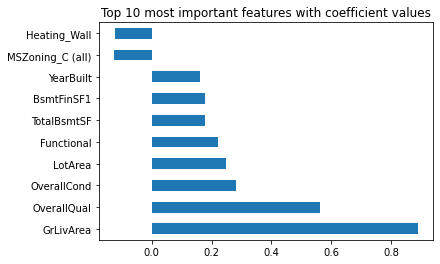

```python
top_10.plot.barh(title="Top 10 most important features with coefficient values");
```

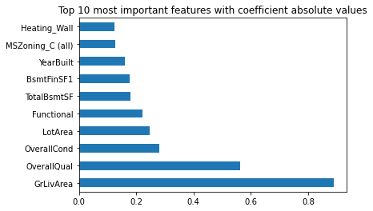

```python
top_10.map(lambda x: abs(x)).plot.barh(title="Top 10 most important features with coefficient absolute values");
```

#### Top 10 features

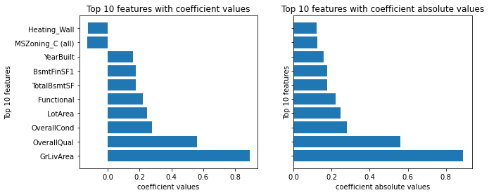

```python
fig, axes = plt.subplots(1, 2, sharey=True, figsize=(10,4))

axes[0].barh(top_10.index, top_10.values)
axes[0].set_title("Top 10 features with coefficient values")
axes[0].set_xlabel("coefficient values")
axes[0].set_ylabel("Top 10 features")

axes[1].barh(top_10.index, np.abs(top_10.values))
axes[1].set_title("Top 10 features with coefficient absolute values")
axes[1].set_xlabel("coefficient absolute values")
axes[1].set_ylabel("Top 10 features")
```

#### Eliminated features

```python
eliminated_features = sorted_coeffs[sorted_coeffs == 0]
eliminated_features.name = "LASSO CV eliminated features"

print(eliminated_features.sort_index().to_string())
```

```
Alley                  -0.0
BedroomAbvGr           -0.0
BldgType_2fmCon        -0.0
BsmtCond                0.0
BsmtHalfBath            0.0
BsmtUnfSF              -0.0
Condition1_Feedr       -0.0
Condition1_RRAe        -0.0
Condition1_RRAn        -0.0
Condition1_RRNe        -0.0
Condition1_RRNn        -0.0
Condition2_Feedr       -0.0
Condition2_Norm        -0.0
Condition2_PosA         0.0
Condition2_PosN         0.0
Condition2_RRAe        -0.0
Condition2_RRAn        -0.0
Condition2_RRNn         0.0
Electrical_FuseF        0.0
Electrical_FuseP        0.0
Electrical_SBrkr       -0.0
Electrical_nan          0.0
Exterior1st_AsphShn     0.0
Exterior1st_BrkComm     0.0
Exterior1st_CBlock      0.0
Exterior1st_CemntBd     0.0
Exterior1st_HdBoard    -0.0
Exterior1st_ImStucc    -0.0
Exterior1st_MetalSd     0.0
Exterior1st_Plywood    -0.0
Exterior1st_PreCast     0.0
Exterior1st_Stone      -0.0
Exterior1st_Stucco      0.0
Exterior1st_VinylSd     0.0
Exterior1st_WdShing     0.0
Exterior2nd_AsphShn     0.0
Exterior2nd_Brk Cmn     0.0
Exterior2nd_BrkFace    -0.0
Exterior2nd_HdBoard     0.0
Exterior2nd_ImStucc     0.0
```

[output cut: 72 more lines]

```
RoofMatl_WdShake       -0.0
RoofMatl_WdShngl        0.0
RoofStyle_Gable         0.0
RoofStyle_Gambrel      -0.0
RoofStyle_Shed         -0.0
SaleType_CWD           -0.0
SaleType_Con            0.0
SaleType_ConLI         -0.0
SaleType_ConLw         -0.0
SaleType_VWD           -0.0
Street                 -0.0
TotRmsAbvGrd            0.0
Utilities               0.0
X2ndFlrSF               0.0
X3SsnPorch              0.0
```

#### Selected 2 top features

```python
top_10.head(2)
```

```
GrLivArea      0.890844
OverallQual    0.561385
Name: LASSO CV regression features coefficients, dtype: float64
```

GrLivArea: Above grade (ground) living area square feet - makes sense.

OverallQual: Rates the overall material and finish of the house - makes sense as well.

#### Selected 2 eliminated features

Wybrałam losowo 2 spośród wyeliminowanych cech przy wykonując `eliminated_features.sample(2)`. Wylosowane cechy:

LotConfig_FR3 -0.0 Neighborhood_NWAmes -0.0 Name: LASSO CV eliminated features, dtype: float64

##### Cecha "LotConfig_FR3"

Cecha "LotConfig_FR3" powstała przy one-hot-encodingu cechy kategorycznej "LotConfig" - konkretnie oznacza ona położenie domu typu *triple frontage*, czyli na skraju 3 dróg. Jak widzimy z poniższego wykresu kołowego, taka sytuacja (kolor czerwony) jest bardzo rzadka (14 spośród 2922 domów) => można więc poczynić założenie, że jest to cecha nieistotna i ją wyeliminować.

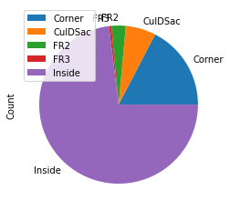

```python
grouped_by_lotconfig = df.groupby(by="LotConfig") # Groupby LotConfig Feature, returns all other features
grouped_by_lotconfig = grouped_by_lotconfig.count().iloc[:, :1] # Pick the first columnn
grouped_by_lotconfig.rename(columns={"MSSubClass": "Count"}, inplace=True) # Rename the first column
grouped_by_lotconfig.plot(kind='pie', subplots=True);
```

```python
print(f"There are {len(df[df['LotConfig'] == 'FR3'])} samples of houses with FR3 type of LotConfig.")
print(f"While there are {len(df[df['LotConfig'] == 'Corner'])} samples of houses with corner type of LotConfig.")
```

```
There are 14 samples of houses with FR3 type of LotConfig.
While there are 508 samples of houses with corner type of LotConfig.
```

##### Cecha "Neighborhood_NWAmes"

Cecha "Neighborhood_NWAmes" powstała przy one-hot-encodingu cechy kategorycznej "Neighborhood", oznaczającej fizyczne lokalizację domu w mieście, w tym wypadku NWAmes - Northwest Ames. Możnaby się spodziewać, że lokalizacja domu jest jednym z najważniejszych czynników decydujących o jego cenie. Widać jednak, że w mieście jest tyle możliwych kategorii lokalizacji, że liczba próbek domów staje się zbyt mała, by ich lokalizacja wpływała na cenę.

[figure not shown]

```python
grouped_by_neighborhood = df.groupby(by="Neighborhood") # Groupby Neighborhood Feature, returns all other features
grouped_by_neighborhood = grouped_by_neighborhood.count().iloc[:, :1] # Pick the first columnn
grouped_by_neighborhood.rename(columns={"MSSubClass": "Count"}, inplace=True) # Rename the first column
grouped_by_neighborhood.plot(kind='pie', subplots=True);
```

## Regresja wielomianowa

Regresja wielomianowa to po prostu dodanie wielomianów cech do naszych danych: $$ [a, b, c, d] -> [a, b, c, d, a^2, b^2, c^2, d^2, ab, ac, ad, bc, bd, cd] $$

W Scikit-learn regresja wielomianowa składa się z 2 osobnych kroków: wygenerowania cech wielomianowych i użycia zwykłej regresji liniowej. Pozwala to na użycie tej transformacji dla dowolnych algorytmów, nie tylko regresji liniowej.

Kwestią sporną jest, czy jest sens przeprowadzać taką transformację dla zmiennych po one-hot encodingu. Potęgi na pewno nie mają sensu, natomiast interakcje realizują po prostu operację koniunkcji (AND), ale łatwo prowadzi to do eksplozji wymiarowości. Dla uproszczenia poniżej zastosujemy transformację dla wszystkich cech.

Warto pamiętać, że jeżeli używamy modelu, który sam dodaje intercept (jak regresja liniowa), to trzeba przekazać `include_bias=False`. Żeby wymiarowość nam nie urosła zbyt bardzo, użyjemy `interaction_only=True`.

```python
from sklearn.preprocessing import PolynomialFeatures

poly_features = PolynomialFeatures(degree=2, interaction_only=True, include_bias=False)
poly_features.fit(X_train)

X_train_poly = poly_features.transform(X_train)
X_test_poly = poly_features.transform(X_test)

reg_ridge_cv_poly = RidgeCV(alphas=np.linspace(0.1, 100, 1000))
reg_ridge_cv_poly.fit(X_train_poly, y_train)

assess_regression_model(reg_ridge_cv_poly, X_train_poly, X_test_poly, y_train, y_test)
print()
print(f"Ridge + polynomial features alpha: {reg_ridge_cv_poly.alpha_:.4f}")
```

```
Train RMSE after np.expm1 on y: 12856.88
Test RMSE after np.expm1 on y: 18298.30

Ridge + polynomial features alpha: 84.8000
```

Co ciekawe, model bardziej zbliżył się do przeuczenia, ale błąd testowy zmalał. Jest to niezbyt częste, ale możliwe.

## Regresja logistyczna

Do klasyfikacji wykorzystamy zbiór [Bank Marketing](https://archive.ics.uci.edu/ml/datasets/bank+marketing), w którym przewiduje się, czy dana osoba będzie zainteresowana lokatą terminową w banku. Precyzyjny targetowany marketing jest ważny z perspektywy biznesu, bo w praktyce chce się reklamować tak mało, jak to możliwe. Bank zarabia tylko na tych osobach, które są faktycznie zainteresowane reklamą, a pozostałych można łatwo zrazić zbyt dużą liczbą reklam, więc precyzyjna ocena przynosi tu realne zyski.

Opisy zmiennych znajdują się w pliku `bank_marketing_description.txt`.

**Zadanie 7 (1 punkt)**

*Wczytywanie i czyszczenie danych*

1. Załaduj zbiór danych z pliku `bank_marketing_data.csv` do DataFrame'a. Zwróć uwagę, że separatorem jest średnik (argument `sep`).
2. Usuń kolumny:
   - `default`, czy klient ma zadłużenie na karcie kredytowej; ma tylko 3 wartości `yes`
   - `duration`, czas trwania ostatniego telefonu reklamowego; autorzy sugerują usunięcie w opisie zbioru, bo nie znamy tej wartości przed wykonaniem telefonu
   - `pdays`, liczba dni od ostatniego telefonu reklamowego w ramach danej kampanii marketingowej; jeżeli to pierwszy kontakt, to wartość to 999, i ciężko byłoby włączyć taką cechę do modelu, a mamy już i tak informację o tym, czy to pierwszy kontakt z klientem w zmiennej `previous`
   - `poutcome`, wynik poprzedniej kampanii; w zdecydowanej większości przypadków to `nonexistent`
3. Dokonaj filtrowania wierszy:
   - usuń wiersze z `education` na poziomie `illiterate`, jest ich tylko kilkanaście
4. Zakoduj odpowiednio zmienne `education`, `contact`, `month`, `day_of_week` i `y`. Dla ułatwienia słowniki są w zmiennych poniżej.
5. Wyodrębnij kolumnę `y` do zmiennej `y` (pamiętaj o usunięciu jej z DataFrame'a).

```python
education_mapping = {
    "basic.4y": "primary",
    "basic.6y": "primary",
    "basic.9y": "primary",
    "high.school": "secondary",
    "professional.course": "secondary",
    "university.degree": "tertiary",
}

contact_mapping = {
    "telephone": 0,
    "cellular": 1,
}

month_mapping = {
    "jan": 1,
    "feb": 2,
    "mar": 3,
    "apr": 4,
    "may": 5,
    "jun": 6,
    "jul": 7,
    "aug": 8,
    "sep": 9,
    "oct": 10,
    "nov": 11,
    "dec": 12,
}

day_of_week_mapping = {
    "mon": 1,
    "tue": 2,
    "wed": 3,
    "thu": 4,
    "fri": 5,
}

y_mapping = {
    "no": 0,
    "yes": 1,
}
```

```python
# read the csv files seprated by ;
bank_df = pd.read_csv("bank_marketing_data.csv", sep=";")
print(bank_df.shape)
head = bank_df.head()

# drop some less relevant collumns
bank_df = bank_df.drop(["default", "duration", "pdays", "poutcome"], axis="columns")
print(bank_df.shape)
head

# delete rows where education is illiterate
bank_df = bank_df.loc[~bank_df["education"].isin(["illiterate"])]
print(bank_df.shape)
bank_df.head()
```

```
(41188, 21)
(41188, 17)
(41170, 17)
```

|  | age | job | marital | education | housing | loan | contact | month | day_of_week | campaign | previous | emp.var.rate | cons.price.idx | cons.conf.idx | euribor3m | nr.employed | y |
| --- | --- | --- | --- | --- | --- | --- | --- | --- | --- | --- | --- | --- | --- | --- | --- | --- | --- |
| 0 | 56 | housemaid | married | basic.4y | no | no | telephone | may | mon | 1 | 0 | 1.1 | 93.994 | -36.4 | 4.857 | 5191.0 | no |
| 1 | 57 | services | married | high.school | no | no | telephone | may | mon | 1 | 0 | 1.1 | 93.994 | -36.4 | 4.857 | 5191.0 | no |
| 2 | 37 | services | married | high.school | yes | no | telephone | may | mon | 1 | 0 | 1.1 | 93.994 | -36.4 | 4.857 | 5191.0 | no |
| 3 | 40 | admin. | married | basic.6y | no | no | telephone | may | mon | 1 | 0 | 1.1 | 93.994 | -36.4 | 4.857 | 5191.0 | no |
| 4 | 56 | services | married | high.school | no | yes | telephone | may | mon | 1 | 0 | 1.1 | 93.994 | -36.4 | 4.857 | 5191.0 | no |

```python
mappings = [education_mapping, contact_mapping, month_mapping, day_of_week_mapping, y_mapping]
cols_to_map = ["education", "contact", "month", "day_of_week", "y"]

for col, mapping in zip(cols_to_map, mappings):
    bank_df = bank_df.replace({col : mapping})

# bank_df = bank_df.replace(
#     {
#         "education": education_mapping,
#         "contact": contact_mapping,
#         "month": month_mapping,
#         "day_of_week": day_of_week_mapping,
#         "y": y_mapping,
#     }
# )
```

```python
bank_y = bank_df.pop("y")
```

**Zadanie 8 (0.5 punktu)**

*Exploratory Data Analysis (EDA)*

1. Sprawdź, czy są jakieś wartości brakujące za pomocą biblioteki `missingno`. Jeżeli tak, to sprawdź w dokumentacji zbioru, jaka byłaby sensowna wartość do ich uzupełnienia.
2. Narysuj wykres (bar plot) z częstością klas. Uwzględnij częstość na wykresie ([to może się przydać](https://stackoverflow.com/a/68107610/9472066)). Pamiętaj o tytule i opisaniu osi.

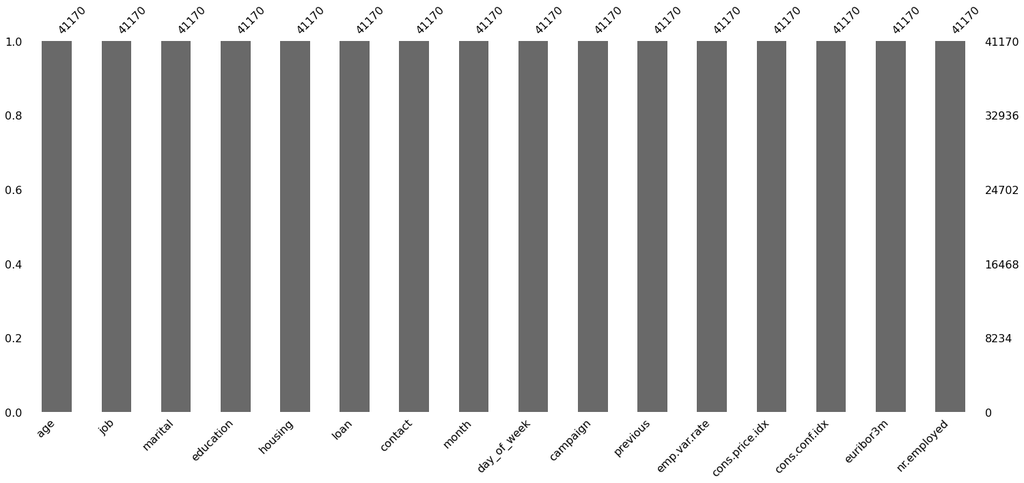

```python
import missingno as msno

msno.bar(bank_df)
```

```python
bank_df.info()
```

```
<class 'pandas.core.frame.DataFrame'>
Int64Index: 41170 entries, 0 to 41187
Data columns (total 16 columns):
 #   Column          Non-Null Count  Dtype
---  ------          --------------  -----
 0   age             41170 non-null  int64
 1   job             41170 non-null  object
 2   marital         41170 non-null  object
 3   education       41170 non-null  object
 4   housing         41170 non-null  object
 5   loan            41170 non-null  object
 6   contact         41170 non-null  int64
 7   month           41170 non-null  int64
 8   day_of_week     41170 non-null  int64
 9   campaign        41170 non-null  int64
 10  previous        41170 non-null  int64
 11  emp.var.rate    41170 non-null  float64
 12  cons.price.idx  41170 non-null  float64
 13  cons.conf.idx   41170 non-null  float64
 14  euribor3m       41170 non-null  float64
 15  nr.employed     41170 non-null  float64
dtypes: float64(5), int64(6), object(5)
memory usage: 5.3+ MB
```

```python
bank_df.isna().sum()
```

```
age               0
job               0
marital           0
education         0
housing           0
loan              0
contact           0
month             0
day_of_week       0
campaign          0
previous          0
emp.var.rate      0
cons.price.idx    0
cons.conf.idx     0
euribor3m         0
nr.employed       0
dtype: int64
```

```python
[x for x in bank_y.isna() if x is True]
```

```
[]
```

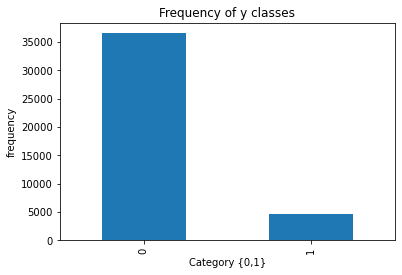

```python
# Vertical plot
ax = bank_y.value_counts().plot.bar(title="Frequency of y classes", xlabel="Category {0,1}", ylabel='frequency')
```

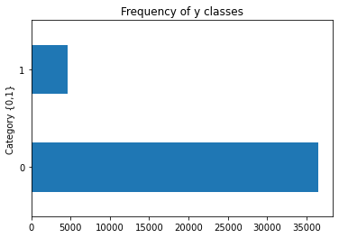

```python
# Horizontal plot
ax = bank_y.value_counts().plot.barh(title="Frequency of y classes", xlabel="Category {0,1}", ylabel='frequency')
```

Jak widać, będziemy tu mieli do czynienia z problemem klasyfikacji niezbalansowanej. Na szczęście funkcja kosztu w regresji logistycznej pozwala na dodanie **wag klas (class weights)**, aby przypisać większą wagę interesującej nas klasie pozytywnej. Scikit-learn dla wartości `class_weights="balanced"` obliczy wagi odwrotnie proporcjonalne do częstości danej klasy w zbiorze.

**Zadanie 9 (1 punkt)**

*Podział i preprocessing danych*

1. Dokonaj podziału zbioru na treningowy i testowy w proporcjach 75%-25%. Pamiętaj o użyciu podziału ze stratyfikacją (argument `stratify`), aby zachować proporcje klas. Ustaw `random_state=0`.
2. Stwórz `ColumnTransformer`, przetwarzający zmienne kategoryczne za pomocą `OneHotEncoder` (teraz już nie musimy robić `drop="first"`), a numeryczne za pomocą `StandardScaler`. Zaaplikuj go do odpowiednich kolumn.

```python
X_train, X_test, y_train, y_test = train_test_split(
    bank_df, bank_y, test_size=0.25, random_state=0, stratify=bank_y
)

categorical_features = bank_df.select_dtypes(include="object").columns
numerical_features = bank_df.select_dtypes(exclude="object").columns
```

```python
from sklearn.preprocessing import OneHotEncoder, StandardScaler
from sklearn.pipeline import make_pipeline
from sklearn.compose import make_column_transformer

column_transformer = make_column_transformer((OneHotEncoder(), categorical_features), (StandardScaler(), numerical_features))
```

```python
X_train = column_transformer.fit_transform(X_train)
X_test = column_transformer.transform(X_test)
```

**Zadanie 10 (2.5 punktu)**

*Trening, tuning i analiza modeli*

1. Wytrenuj podstawowy model regresji logistycznej z użyciem `LogisticRegression`. Użyj wag klas (`class_weights="balanced"`). Przetestuj model, wypisując AUROC w procentach. **Uwaga:** Scikit-learn domyślnie stosuje tutaj regularyzację L2, więc przekaż `penalty=None`.
2. Dokonaj tuningu modelu z regularyzacją L2 za pomocą `LogisticRegressionCV`:
   - sprawdź 100 wartości, wystarczy podać liczbę do `Cs`
   - użyj 5-krotnej walidacji skrośnej
   - wybierz najlepszy model według metryki AUROC (parametr `scoring`)
   - pamiętaj o `class_weights="balanced"` i `random_state=0`
   - użyj `n_jobs=-1` dla przyspieszenia obliczeń
   - przetestuj model, wypisując AUROC w procentach
   - **uwaga:** Scikit-learn stosuje tutaj konwencję, gdzie parametr `C` to odwrotność siły regularyzacji - im mniejszy, tym silniejsza regularyzacja.
3. Dokonaj analogicznego tuningu, ale dla regularyzacji L1. Użyj solwera SAGA. Przetestuj model, wypisując AUROC w procentach.
4. Dokonaj analizy wytrenowanych modeli:
   - narysuj poziomy wykres słupkowy 10 najważniejszych cech przy użyciu regularyzacji L2, pamiętaj o opisaniu nazw cech, osi i tytule; zwróć uwagę, że wektor współczynników musi być jednowymiarowy
   - wypisz, ile procent cech zostało wyeliminowanych przy użyciu regularyzacji L1, oraz wypisz posortowaną listę nazw tych cech
   - dokonaj interpretacji 2 wybranych cech spośród najlepszych oraz 2 wybranych spośród tych wyeliminowanych - czy ma to twoim zdaniem sens?
   - oblicz AUROC na zbiorze treningowym modelu bez żadnej regularyzacji i porównaj go z wynikiem testowym; czy występuje tutaj overfitting?
   - czy twoim zdaniem tworzenie modeli z regularyzacją ma sens w tym przypadku?

```python
from sklearn.linear_model import LogisticRegression, LogisticRegressionCV
from sklearn.metrics import roc_auc_score
```

#### Logistic Regression without tuning

```python
reg_logistic = LogisticRegression(class_weight="balanced", penalty=None)
reg_logistic.fit(X_train, y_train)

y_pred = reg_logistic.predict(X_test)
# y_pred_proba = reg_logistic.predict_proba(X_test) # Probability estimates
# y_dec = reg_logistic.decision_function(X_test) # Predict cofidence scores for samples
auroc = roc_auc_score(y_test, y_pred)

print(f"AUROC: {auroc*100:.2f}%")
```

```
AUROC: 71.59%
```

#### Cross-validated Logistic Regression with C-tuning w.r.t. L2

```python
# roc_auc_ovr, roc_auc, roc_auc_ovo_weighted, roc_auc_ovo, roc_auc_ovr_weighted -> metrics.roc_auc_score
reg_logistic_cv = LogisticRegressionCV(Cs=100, cv=5, class_weight="balanced", random_state=0, n_jobs=-1, scoring="roc_auc")
reg_logistic_cv.fit(X_train, y_train);
```

```python
y_pred_cv = reg_logistic_cv.predict(X_test)
auroc_score_cv = reg_logistic_cv.score(X_test, y_test)
print(f"Score (AUROC): {auroc_score_cv * 100: .2f}%")
```

```
Score (AUROC):  77.14%
```

#### Cross-validated Logistic Regression with C-tuning w.r.t. L1 with SAGA solver

```python
reg_logistic_cv_L1 = LogisticRegressionCV(Cs=100, cv=5, class_weight="balanced", random_state=0, n_jobs=-1, scoring="roc_auc", penalty='l1', solver='saga')
reg_logistic_cv_L1.fit(X_train, y_train);
```

```python
y_pred_cv_L1 = reg_logistic_cv_L1.predict(X_test)
auroc_score_cv_L1 = reg_logistic_cv_L1.score(X_test, y_test)
print(f"Score (AUROC): {auroc_score_cv_L1 * 100: .2f}%")
```

```
Score (AUROC):  77.09%
```

### Models' assesment

##### Top 10 features (L2)

```python
column_transformer.get_feature_names_out()
```

```
array(['onehotencoder__job_admin.', 'onehotencoder__job_blue-collar',
       'onehotencoder__job_entrepreneur', 'onehotencoder__job_housemaid',
       'onehotencoder__job_management', 'onehotencoder__job_retired',
       'onehotencoder__job_self-employed', 'onehotencoder__job_services',
       'onehotencoder__job_student', 'onehotencoder__job_technician',
       'onehotencoder__job_unemployed', 'onehotencoder__job_unknown',
       'onehotencoder__marital_divorced',
       'onehotencoder__marital_married', 'onehotencoder__marital_single',
       'onehotencoder__marital_unknown',
       'onehotencoder__education_primary',
       'onehotencoder__education_secondary',
       'onehotencoder__education_tertiary',
       'onehotencoder__education_unknown', 'onehotencoder__housing_no',
       'onehotencoder__housing_unknown', 'onehotencoder__housing_yes',
       'onehotencoder__loan_no', 'onehotencoder__loan_unknown',
       'onehotencoder__loan_yes', 'standardscaler__age',
       'standardscaler__contact', 'standardscaler__month',
       'standardscaler__day_of_week', 'standardscaler__campaign',
       'standardscaler__previous', 'standardscaler__emp.var.rate',
       'standardscaler__cons.price.idx', 'standardscaler__cons.conf.idx',
       'standardscaler__euribor3m', 'standardscaler__nr.employed'],
      dtype=object)
```

```python
# Remove prefixes from feature names in column_transformer
feature_names = pd.Series(column_transformer.get_feature_names_out())
feature_names = feature_names.map(lambda x: x.replace('standardscaler__', '')).map(lambda x: x.replace("onehotencoder__", ''))
```

```python
coeffs_logreg_cv_L2 = pd.Series(reg_logistic_cv.coef_.flatten(), index=feature_names, name="Logistic Regression CV L2 feature coefficients")

sorted_coeffs = coeffs_logreg_cv_L2.sort_values(key=lambda x: abs(x), ascending=False)
top_10 = sorted_coeffs.head(10)
```

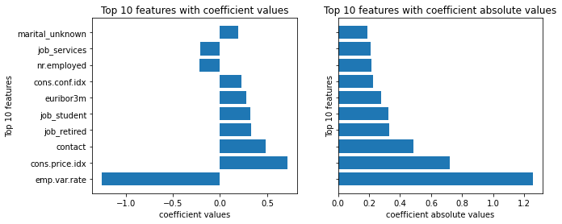

```python
fig, axes = plt.subplots(1, 2, sharey=True, figsize=(10,4))

axes[0].barh(top_10.index, top_10.values)
axes[0].set_title("Top 10 features with coefficient values")
axes[0].set_xlabel("coefficient values")
axes[0].set_ylabel("Top 10 features")

axes[1].barh(top_10.index, np.abs(top_10.values))
axes[1].set_title("Top 10 features with coefficient absolute values")
axes[1].set_xlabel("coefficient absolute values")
axes[1].set_ylabel("Top 10 features")
```

##### Eliminated features (L1)

```python
coeff_l1_zero_perc = np.sum(reg_logistic_cv_L1.coef_.flatten() == 0) / len(reg_logistic_cv_L1.coef_.flatten())

print("Percentage of eliminated features with LogisticRegressionCV L1 SAGA solver:")
print(f"{100 * coeff_l1_zero_perc:.2f}%")
```

```
Percentage of eliminated features with LogisticRegressionCV L1 SAGA solver:
45.95%
```

```python
eliminated_features = pd.Series(reg_logistic_cv_L1.coef_.flatten(), index=feature_names)
eliminated_features = eliminated_features[eliminated_features == 0]
eliminated_features = eliminated_features.sort_index()
eliminated_features
```

```
age                  0.0
euribor3m            0.0
housing_unknown      0.0
housing_yes          0.0
job_admin.           0.0
job_entrepreneur     0.0
job_housemaid        0.0
job_management       0.0
job_self-employed    0.0
job_technician       0.0
job_unemployed       0.0
job_unknown          0.0
loan_no              0.0
loan_unknown         0.0
loan_yes             0.0
marital_divorced     0.0
marital_unknown      0.0
dtype: float64
```

##### Selected 2 top features

```python
top_10.head(2)
```

```
emp.var.rate     -1.256397
cons.price.idx    0.717501
Name: Logistic Regression CV L2 feature coefficients, dtype: float64
```

Obydwa wskaźniki należą do grupy socjo-ekonomicznych - wydaje się to być ważna grupa:

- emp.var.rate: employment variation rate - quarterly indicator (numeric) - niestety nie jest opisana w dokumentacji do zbioru,
- cons.price.idx: consumer price index - monthly indicator (numeric) - a measure of the average change over time in the prices paid by urban consumers for a market basket of consumer goods and services.

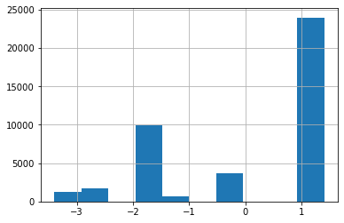

```python
bank_df["emp.var.rate"].hist()
```

Z powyższego histogramu wynika, że najpopularniejszą wartością tej zmiennej jest 1 - można to interpretować jako utrzymanie tej samej pracy w ciągu kwartału (?). Ujemne coefficient value dla tej zmiennej może oznaczać, że preferujemy niską fluktuację zatrudnienia - małą liczbę zmian pracy w ciągu kwartału, a więc może tylko jedną i tę samą pracę. Przy tej interpretacji ma to sens, ale nie jestem pewna, czy jest ona poprawna.

Z kolei zmienna consumer price index wydaje się być adekwatna do celów naszej predykcji.

##### Selected 2 eliminated features

Wybrałam losowo 2 spośród wyeliminowanych cech przy wykonując `eliminated_features.sample(2)`. Wylosowane cechy:

job_management 0.0 euribor3m 0.0 dtype: float64

- job_management

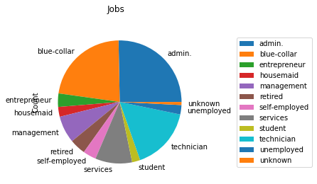

```python
grouped = bank_df.groupby(by="job") # Groupby
grouped = grouped.count().iloc[:, :1] # Pick the first columnn
grouped.rename(columns={"age": "Count"}, inplace=True) # Rename the first column
grouped.plot(kind='pie', subplots=True, title="Jobs");
plt.legend(loc="center", bbox_to_anchor=(1.5, 0.5));
```

Z powyższego wykresu wynika, że faktycznie praca typu "management" jest wartością stosunkowo rzadką - jest ok. 4-5 pod względem częstości, więc nie jest też aż tak nieważna. Ale usunięcie jej moze mieć sens w obliczu innych, ważniejszych cech.

- euribor3m - euribor 3 month rate

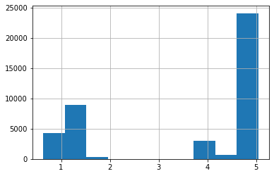

```python
bank_df["euribor3m"].hist()
```

EURIBOR (ang. Euro Interbank Offered Rate) – referencyjna wysokość oprocentowania depozytów i kredytów na rynku międzybankowym strefy euro. Ciężko oszacować wartościowość tej cechy na podstawie powyższego histogramu.

##### AUROC on training and test sets -> overfitting check-up

```python
def asses_logistic_regression_model(model, X_train, X_test, y_train, t_test, score=roc_auc_score) -> None:
    # predict for train and test
    y_pred_train = model.predict(X_train)
    y_pred = model.predict(X_test)

    # calculate AUROC
    auroc_train = roc_auc_score(y_train, y_pred_train)
    auroc = roc_auc_score(y_test, y_pred)

    # print train and test AUROC score
    print(f"Train AUROC: {auroc_train * 100:.2f}%")
    print(f"Test AUROC: {auroc * 100: .2f}%")
```

```python
asses_logistic_regression_model(reg_logistic, X_train, X_test, y_train, y_test)
```

```
Train AUROC: 72.38%
Test AUROC:  71.59%
```

**Zadanie 11 (1.5 punktu)**

*Dodanie cech wielomianowych do regresji logistycznej*

1. Stwórz nowy pipeline do przetwarzania danych do regresji logistycznej, dodając `PolynomialFeatures` do zmiennych numerycznych przed standaryzacją. Wygeneruj cechy o stopniu 2, interakcje oraz potęgi, nie generuj interceptu.
2. Wytrenuj model regresji logistycznej bez regularyzacji na takim powiększonym zbiorze. Wypisz AUROC treningowy oraz testowy w procentach.
3. Zdecyduj, czy jest sens tworzyć modele z regularyzacją. Jeżeli tak, to wytrenuj i dokonaj tuningu takich modeli. Jeżeli nie, to uzasadnij czemu.

```python
def feature_names_cleanup(column_transformer):
    # Remove prefixes from feature names in column_transformer
    feature_names = pd.Series(column_transformer.get_feature_names_out())
    feature_names = feature_names.map(lambda x: x.replace('standardscaler__', '')).map(lambda x: x.replace("onehotencoder__", ''))
    return feature_names

def get_sorted_coeffs(model, feature_names, name):
    coeffs = pd.Series(model.coef_.flatten(), index=feature_names, name=name)
    sorted_coeffs = coeffs.sort_values(key=lambda x: abs(x), ascending=False)
    top_10 = sorted_coeffs.head(10)
    return top_10

def plot_top_10_features(top_10):
    fig, axes = plt.subplots(1, 2, sharey=True, figsize=(18,6))

    axes[0].barh(top_10.index, top_10.values)
    axes[0].set_title("Top 10 features with coefficient values")
    axes[0].set_xlabel("coefficient values")
    axes[0].set_ylabel("Top 10 features")

    axes[1].barh(top_10.index, np.abs(top_10.values))
    axes[1].set_title("Top 10 features with coefficient absolute values")
    axes[1].set_xlabel("coefficient absolute values")
    axes[1].set_ylabel("Top 10 features")


def get_eliminated_features(model, feature_names):
    coeff_zero_perc = np.sum(model.coef_.flatten() == 0) / len(model.coef_.flatten())
    print("Percentage of eliminated features:")
    print(f"{100 * coeff_zero_perc:.2f}%")

    eliminated_features = pd.Series(model.coef_.flatten(), index=feature_names)
    eliminated_features = eliminated_features[eliminated_features == 0]
    eliminated_features = eliminated_features.sort_index()
    return eliminated_features


def sum_up(model, column_transformer, name):
    feature_names = feature_names_cleanup(column_transformer) # Cleanup from column transformer dust
    top_10 = get_sorted_coeffs(model, feature_names, name) # Get top 10 (for simplicity) features
    plot_top_10_features(top_10) # Plot them
    eliminated_features = get_eliminated_features(model, feature_names)
    return eliminated_features
```

#### Polynomial pipeline

```python
from sklearn.preprocessing import PolynomialFeatures

X_train, X_test, y_train, y_test = train_test_split(
    bank_df, bank_y, test_size=0.25, random_state=0, stratify=bank_y
)

categorical_features = bank_df.select_dtypes(include="object").columns
numerical_features = bank_df.select_dtypes(exclude="object").columns

poly = PolynomialFeatures(2, interaction_only=True, include_bias = False)
poly_column_transformer = make_column_transformer((OneHotEncoder(), categorical_features), (poly, numerical_features), (StandardScaler(), numerical_features))

X_train = poly_column_transformer.fit_transform(X_train)
X_test = poly_column_transformer.transform(X_test)

print(f'PolynomialFeatures no. {X_train.shape[1]}')
```

```
PolynomialFeatures no. 103
```

#### Model training

##### Without regularisation

```python
name = "Logistic Regression without tuning with PolynomialFeatures"

reg_logistic_poly = LogisticRegression(class_weight="balanced", penalty=None)
reg_logistic_poly.fit(X_train, y_train);

print(name)
asses_logistic_regression_model(reg_logistic_poly, X_train, X_test, y_train, y_test)
```

```
Logistic Regression without tuning with PolynomialFeatures
Train AUROC: 71.01%
Test AUROC:  70.03%
```

Jak widać, różnica między treningowym i testowym AUROC wynosi mniej niż 1%. Wartości AUROC są jednak niższe niż przed dodaniem cech wielomianowych. Nie zaszkodzi jednak sprawdzić (poza amortyzacją użytego sprzętu :) oraz czasem), jak wyglądałby trening z regularyzacją.

Tak prezentuje się top 10 wielomianowych cech:

```
Percentage of eliminated features:
0.00%
```

```
Series([], dtype: float64)
```

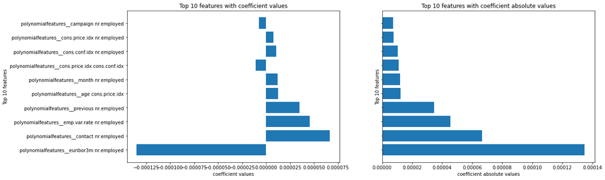

```python
model, column_transformer = reg_logistic_poly, poly_column_transformer
sum_up(model, column_transformer, name)
```

##### Cross-Validated with L2 regularisation

```python
# Cross-validated LogReg with C-tuning w.r.t. L2
reglog_poly_cv = LogisticRegressionCV(Cs=100, cv=5, class_weight="balanced", random_state=0, n_jobs=-1, scoring="roc_auc")
reglog_poly_cv.fit(X_train, y_train);
```

```python
name = "Cross-Validated Logistic Regression with L2 tuning with PolynomialFeatures"
print(name)
asses_logistic_regression_model(reglog_poly_cv, X_train, X_test, y_train, y_test)
```

```
Cross-Validated Logistic Regression with L2 tuning with PolynomialFeatures
Train AUROC: 72.10%
Test AUROC:  71.24%
```

Jak widać, obie wartości AUROC wzrosły, choć wciąż są niższe od wartości bez cech wielomianowych.

```
Percentage of eliminated features:
0.00%
```

```
Series([], dtype: float64)
```

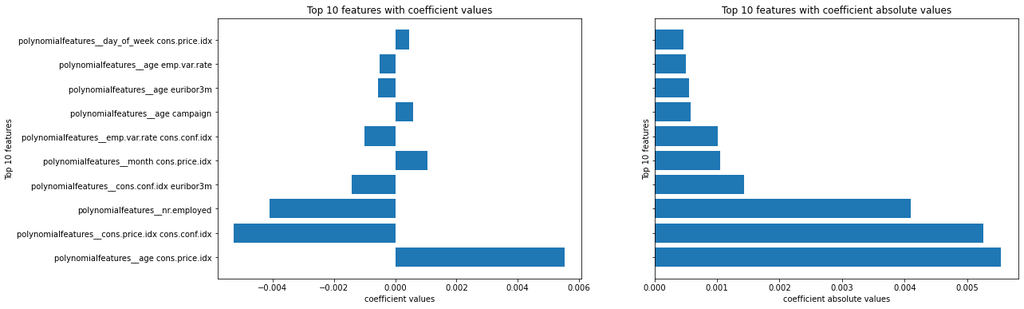

```python
model, column_transformer = reglog_poly_cv, poly_column_transformer
sum_up(model, column_transformer, name)
```

##### Cross-Validated with L1 regularisation

Dla Cs=100 obliczenia nie kończyły się w rozsądnym czasie. Stąd zmniejszono ich liczbę.

```python
# Cross-validated LogReg with C-tuning w.r.t. L1 with SAGA solver
reglog_poly_cv_L1 = LogisticRegressionCV(Cs=10, cv=5, class_weight="balanced", random_state=0, n_jobs=-1, scoring="roc_auc", penalty='l1', solver='saga')
reglog_poly_cv_L1.fit(X_train, y_train);
```

[output not shown]

[output cut: 47 more lines]

[output not shown]

```python
name = "Cross-Validated Logistic Regression with L1 tuning with PolynomialFeatures"
print(name)
asses_logistic_regression_model(reglog_poly_cv_L1, X_train, X_test, y_train, y_test)
```

```
Cross-Validated Logistic Regression with L1 tuning with PolynomialFeatures
Train AUROC: 71.14%
Test AUROC:  70.21%
```

```
Percentage of eliminated features:
0.00%
```

```
Series([], dtype: float64)
```

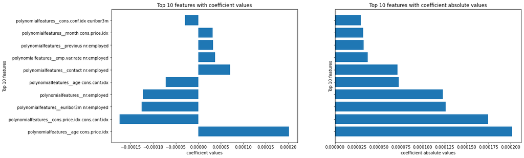

```python
model, column_transformer = reglog_poly_cv_L1, poly_column_transformer
sum_up(model, column_transformer, name)
```

## Zadanie dodatkowe (3 punkty)

Z formalnego, statystycznego punktu widzenia regresja liniowa czyni szereg założeń ([Wikipedia](https://en.wikipedia.org/wiki/Linear_regression#Assumptions)):

1. Liniowość - relacja w danych może być reprezentowana jako `y=Xw`.
2. Normalność błędów - błędy (rezydua) mają rozkład normalny, wycentrowany na zerze.
3. Homoskedastyczność (stała wariancja) - wariancja błędu nie zależy od wartości docelowych `y`. Innymi słowy, nasz błąd będzie w przybliżeniu miał podobny "rozrzut" dla małych i dużych wartości `y`.
4. Niezależność błędów - błąd i `y` są niezależne (w sensie statystycznym). Innymi słowy, nie ma między nimi bezpośredniej relacji. Jeżeli nie pracujemy z szeregami czasowymi, to to założenie po prostu jest spełnione.
5. Brak współliniowości zmiennych - nie ma idealnej korelacji cech.

Testowanie tych własności nie zawsze jest oczywiste, a w szczególności Scikit-learn oferuje tutaj dość mało opcji, bo pochodzą one głównie z tradycyjnej statystyki.

1. Liniowość:
   - numerycznie: wysoki współczynnik dopasowania modelu $R^2$ na zbiorze treningowym, niski błąd (RMSE) na zbiorze treningowym oraz testowym
   - testem statystycznym: [Rainbow test](https://www.statsmodels.org/dev/generated/statsmodels.stats.diagnostic.linear_rainbow.html) lub [Harvey Collier test](https://www.statsmodels.org/stable/generated/statsmodels.stats.diagnostic.linear_harvey_collier.html)
   - graficznie: możliwe kiedy mamy 1/2 zmienne i da się narysować wykres zmiennej zależnej względem cech
2. Normalność błędów:
   - graficznie: robimy histogram rezyduów, powinien mieć kształt rozkładu normalnego i być wycentrowany na zerze
   - testem statystycznym: [Jarque-Bera test](https://en.wikipedia.org/wiki/Jarque%E2%80%93Bera_test), [Omnibus normality test](https://docs.scipy.org/doc/scipy/reference/generated/scipy.stats.normaltest.html)
3. Homoskedastyczność:
   - graficznie: robimy scatter plot rezyduów dla wartości przewidywanych od najmniejszej do największej, nie powinno być na nim żadnych widocznych wzorców czy kształtów; [przykład 1](https://towardsdatascience.com/multivariant-linear-regression-e636a4f99b40), [przykład 2](https://www.vexpower.com/brief/homoskedasticity)
   - testem statystycznym: [Breusch–Pagan test](https://en.wikipedia.org/wiki/Breusch%E2%80%93Pagan_test) lub [Goldfeld-Quandt test](https://en.wikipedia.org/wiki/Goldfeld%E2%80%93Quandt_test)
4. Niezależność błędów - nie omawiam, bo dotyczy tylko szeregów czasowych.
5. Brak współliniowości zmiennych: numerycznie, sprawdzić korelacje zmiennych, lub współczynnik uwarunkowania macierzy `X`

W ramach zadania wytrenuj model regresji liniowej dla zbioru danych Ames Housing z użyciem biblioteki Statsmodels: [OLS docs](https://www.statsmodels.org/dev/generated/statsmodels.regression.linear_model.OLS.html), [OLS](https://www.statsmodels.org/dev/examples/notebooks/generated/ols.html), [Regression diagnostics](https://www.statsmodels.org/dev/examples/notebooks/generated/regression_diagnostics.html). Wytrenuj najpierw model bez regularyzacji, a następnie z regularyzacją L2 oraz L1. Nie przeprowadzaj tuningu, użyj tych wartości siły regularyzacji, które wyznaczyliśmy wcześniej.

Przetestuj założenia za pomocą testów statystycznych: Harvey Collier, Jarque-Bera, Breusch–Pagan. Współliniowość zmiennych zweryfikuj z użyciem współczynnika uwarunkowania. Zastosuj poziom istotności $\alpha=0.05$.

Czy założenia są spełnione w przypadku podstawowego modelu i/lub modeli z regularyzacją? Czy modele regularyzowane w lepszym stopniu spełniają założenia?

```python
# df - from previous tasks;

categorical_features = df.select_dtypes(include="object").columns
numerical_features = df.select_dtypes(exclude="object").columns

X_train, X_test, y_train, y_test = train_test_split(
    df, y, test_size=0.3, random_state=0
)

one_hot_encoder = OneHotEncoder(
    drop="first", sparse_output=False, handle_unknown="ignore"
)
median_imputer = SimpleImputer(strategy="median")
min_max_scaler = MinMaxScaler()

categorical_pipeline = Pipeline([('one_hot_encoder', one_hot_encoder)])
numerical_pipeline = Pipeline([('imputation', median_imputer), ('normalization', min_max_scaler)])
column_transformer = ColumnTransformer([("cat_pipeline", categorical_pipeline, categorical_features), ("num_pipeline", numerical_pipeline, numerical_features)])

X_train = column_transformer.fit_transform(X_train)
X_test = column_transformer.transform(X_test)
```

#### without regularisation

```python
import statsmodels.api as sm
import statsmodels.formula.api as smf
import statsmodels.stats.api as sms
import statsmodels.regression as sreg

import seaborn as sns
from termcolor import colored
```

```python
model = sm.OLS(y_train, X_train)
results = model.fit()
y_pred = results.predict(X_test)

rmse = mean_squared_error(y_test, y_pred, squared=False)
print(f"STATSMODEL RMSE: {rmse:.4f}")
```

```
STATSMODEL RMSE: 0.1159
```

```python
assess_regression_model(results, X_train, X_test, y_train, y_test)
```

```
Train RMSE after np.expm1 on y: 16751.11
Test RMSE after np.expm1 on y: 21318.61
```

```python
print(results.summary())
```

```
                            OLS Regression Results
==============================================================================
Dep. Variable:              SalePrice   R-squared:                       0.940
Model:                            OLS   Adj. R-squared:                  0.933
Method:                 Least Squares   F-statistic:                     124.4
Date:                Sun, 30 Apr 2023   Prob (F-statistic):               0.00
Time:                        23:41:21   Log-Likelihood:                 1816.3
No. Observations:                2045   AIC:                            -3171.
Df Residuals:                    1814   BIC:                            -1872.
Df Model:                         230
Covariance Type:            nonrobust
==============================================================================
                 coef    std err          t      P>|t|      [0.025      0.975]
------------------------------------------------------------------------------
x1            -0.1746      0.124     -1.413      0.158      -0.417       0.068
x2            -0.0635      0.035     -1.797      0.073      -0.133       0.006
x3            -0.0173      0.055     -0.315      0.753      -0.125       0.090
x4             0.1455      0.110      1.328      0.184      -0.069       0.360
x5             0.0727      0.051      1.421      0.155      -0.028       0.173
x6             0.0155      0.054      0.288      0.773      -0.090       0.121
x7             0.0528      0.078      0.681      0.496      -0.099       0.205
x8             0.0187      0.090      0.208      0.835      -0.158       0.195
x9             0.1353      0.061      2.219      0.027       0.016       0.255
x10            0.0545      0.058      0.943      0.346      -0.059       0.168
x11            0.1179      0.059      1.998      0.046       0.002       0.234
x12            0.0814      0.075      1.084      0.279      -0.066       0.229
x13            0.0052      0.077      0.068      0.946      -0.145       0.156
x14            0.1069      0.065      1.645      0.100      -0.021       0.234
x15            0.0092      0.030      0.310      0.756      -0.049       0.068
x16            0.9684      0.157      6.184      0.000       0.661       1.275
x17            1.2428      0.157      7.932      0.000       0.936       1.550
x18            1.1933      0.178      6.710      0.000       0.845       1.542
x19            1.1970      0.157      7.602      0.000       0.888       1.506
x20            1.2312      0.154      7.971      0.000       0.928       1.534
x21            1.1761      0.154      7.644      0.000       0.874       1.478
x22            0.0210      0.020      1.048      0.295      -0.018       0.060
x23            0.0037      0.025      0.148      0.882      -0.045       0.052
x24            0.0064      0.014      0.447      0.655      -0.022       0.034
x25            0.0058      0.013      0.450      0.653      -0.019       0.031
x26           -0.0254      0.017     -1.473      0.141      -0.059       0.008
```

[output cut: 204 more lines]

```
x231           0.1469      0.161      0.915      0.360      -0.168       0.462
x232          -0.1228      0.177     -0.692      0.489      -0.471       0.225
x233           0.1311      0.148      0.884      0.377      -0.160       0.422
x234          -0.0163      0.008     -2.084      0.037      -0.032      -0.001
==============================================================================
Omnibus:                     1012.307   Durbin-Watson:                   2.005
Prob(Omnibus):                  0.000   Jarque-Bera (JB):            35146.460
Skew:                          -1.685   Prob(JB):                         0.00
Kurtosis:                      23.028   Cond. No.                     1.17e+16
==============================================================================

Notes:
[1] Standard Errors assume that the covariance matrix of the errors is correctly specified.
[2] The smallest eigenvalue is 3.82e-28. This might indicate that there are
strong multicollinearity problems or that the design matrix is singular.
```

#### L2 regularisation with alpha = 2.9000

```python
alpha = 2.9000000000000004
reg_ridge_model = sreg.linear_model.OLS(y_train, X_train).fit_regularized(method='elastic_net', alpha=alpha, L1_wt=0)
# reg_ridge_model = sm.OLS(y_train, X_train).fit_regularized(method='elastic_net', alpha=alpha, L1_wt=0)
y_pred_ridge = reg_ridge_model.predict(X_test)
assess_regression_model(reg_ridge_model, X_train, X_test, y_train, y_test)
```

```
Train RMSE after np.expm1 on y: 134218.16
Test RMSE after np.expm1 on y: 136546.63
```

#### L1 regularisation with alpha = 0.0003

```python
alpha = 0.00029464008656836677
reg_lasso_model = sm.OLS(y_train, X_train).fit_regularized(method='elastic_net', alpha=alpha, L1_wt=1)
y_pred_lasso = reg_lasso_model.predict(X_test)
assess_regression_model(reg_lasso_model, X_train, X_test, y_train, y_test)
```

```
Train RMSE after np.expm1 on y: 87915761.81
Test RMSE after np.expm1 on y: 64781.78
```

### Assumption testing

```python
def model_assumptions_testing(model_results, alpha=0.05):
    print(colored(f"{'-'*20} LINEARITY {'-'*20}\n", 'blue'))
    # Linear Harvey-Collier
    try:
        tvalue, pvalue = sms.linear_harvey_collier(model_results)
        print(f"Harvey-Collier tvalue {tvalue} pvalue {pvalue}")
        print(pvalue >= alpha)
    except Exception as exc:
        print(colored(f"Harvey-Coollier failed: {exc}", 'red'))

    # Linear Rainbow Test
    try:
        fstat, pvalue = sm.stats.diagnostic.linear_rainbow(model_results)
        print(f"Rainbow test fstat: {fstat} pvalue: {pvalue}")
        print(pvalue >= alpha)
    except Exception as exc:
        print(colored(f"Linear Rainbow Test failed: {exc}", 'red'))

    print(colored(f"{'-'*20} NORMALITY OF THE RESIDUALS {'-'*20}\n", 'blue'))
    # Jarque-Bera
    try:
        jb, jbpv, skew, kurtosis = sm.stats.stattools.jarque_bera(model_results.resid)
        print(f"Jarque-Bera: {jb:.2f}")
#     name = ["Jarque-Bera", "Chi^2 two-tail prob.", "Skew", "Kurtosis"]
#     test = sms.jarque_bera(results.resid)
#     [f"{n} {t:.2f}" for n, t in zip(name, test)]
    except Exception as exc:
        print(colored(f"Jarque-Bera failed: {exc}", 'red'))


    print(colored(f"{'-'*20} HOMOSCEDASTICITY {'-'*20}\n", 'blue'))
    # Breush-Pagan
    try:
        name = ["Lagrange multiplier statistic", "p-value", "f-value", "f p-value"]
        lms, pvalue, fvalue, fpvalue = sms.het_breuschpagan(model_results.resid, model_results.model.exog)
        test =[lms, pvalue, fvalue, fpvalue]
        print([f"{n} {t:.2f}" for n, t in zip(name, test)])
        print(pvalue >= alpha)
    except Exception as exc:
        print(colored(f"Breush-Pagan failed: {exc}", 'red'))

    print(colored(f"{'-'*20} MULTICOLLINEARITY {'-'*20}\n", 'blue'))
    print(f"Matrix Condition Number: {np.linalg.cond(model_results.model.exog)}")
```

#### Model without regularization

OLS Regression Results ============================================================================== Dep. Variable: SalePrice R-squared: 0.940 Model: OLS Adj. R-squared: 0.933

- For the non-regularized model, R-squared = 0.94 => relatively high.
- RMSE the same as with scikitlearn => STATSMODEL RMSE: 0.1159.

```python
model_assumptions_testing(results)
```

```
-------------------- LINEARITY --------------------

Harvey-Coollier failed: "The initial regressor matrix, x[:skip], issingular. You must use a value of
skip large enough to ensure that the first OLS estimator is well-defined.

Rainbow test fstat: 0.7755159681540632 pvalue: 0.9999369051145828
True
-------------------- NORMALITY OF THE RESIDUALS --------------------

Jarque-Bera: 35146.46
-------------------- HOMOSCEDASTICITY --------------------

['Lagrange multiplier statistic 386.77', 'p-value 0.00', 'f-value 1.84', 'f p-value 0.00']
False
-------------------- MULTICOLLINEARITY --------------------

Matrix Condition Number: 5.776193371606234e+17
```

- Jarque-Bera high score => data do not have a normal distribution.
- (P-value == 0.0 < alpha == 0.05) => no homoscedasticity.
- Very high matrix condition number => multicollinearity.

#### Model with L2 regularisation

```python
model_assumptions_testing(reg_ridge_model)
```

```
-------------------- LINEARITY --------------------

Harvey-Coollier failed: "The initial regressor matrix, x[:skip], issingular. You must use a value of
skip large enough to ensure that the first OLS estimator is well-defined.

Linear Rainbow Test failed: res must be a results instance from a linear model.
-------------------- NORMALITY OF THE RESIDUALS --------------------

Jarque-Bera failed: 'RegularizedResults' object has no attribute 'resid'
-------------------- HOMOSCEDASTICITY --------------------

Breush-Pagan failed: 'RegularizedResults' object has no attribute 'resid'
-------------------- MULTICOLLINEARITY --------------------

Matrix Condition Number: 5.776193371606234e+17
```

```python
model_assumptions_testing(reg_lasso_model)
```

```
-------------------- LINEARITY --------------------

Harvey-Coollier failed: "The initial regressor matrix, x[:skip], issingular. You must use a value of
skip large enough to ensure that the first OLS estimator is well-defined.

Linear Rainbow Test failed: res must be a results instance from a linear model.
-------------------- NORMALITY OF THE RESIDUALS --------------------

Jarque-Bera failed: 'RegularizedResults' object has no attribute 'resid'
-------------------- HOMOSCEDASTICITY --------------------

Breush-Pagan failed: 'RegularizedResults' object has no attribute 'resid'
-------------------- MULTICOLLINEARITY --------------------

Matrix Condition Number: 5.776193371606234e+17
```